# GLMM Analysis for Circle Time

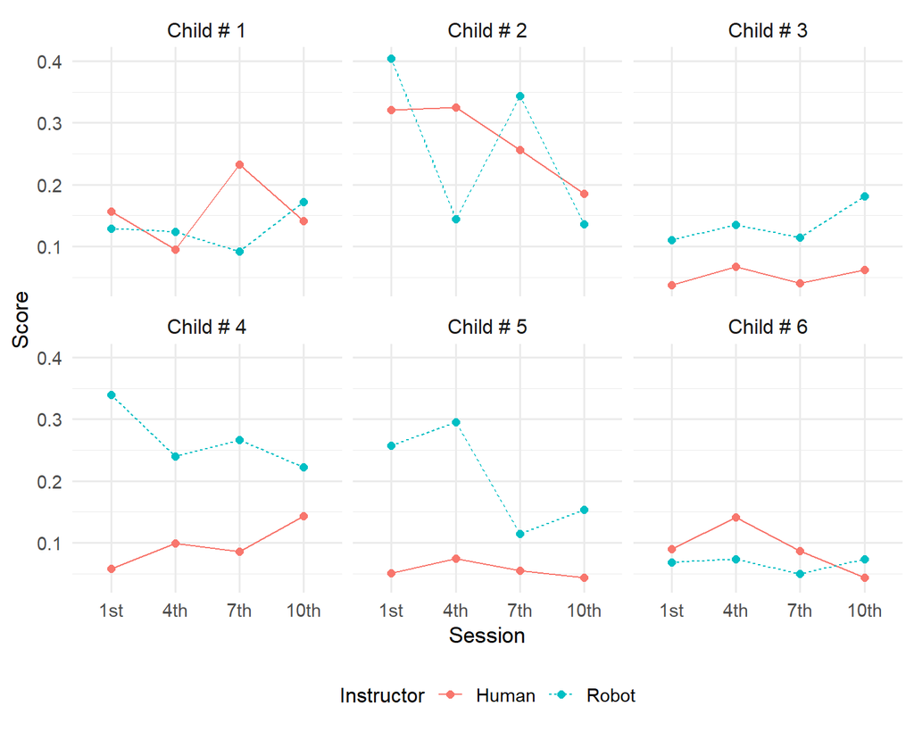

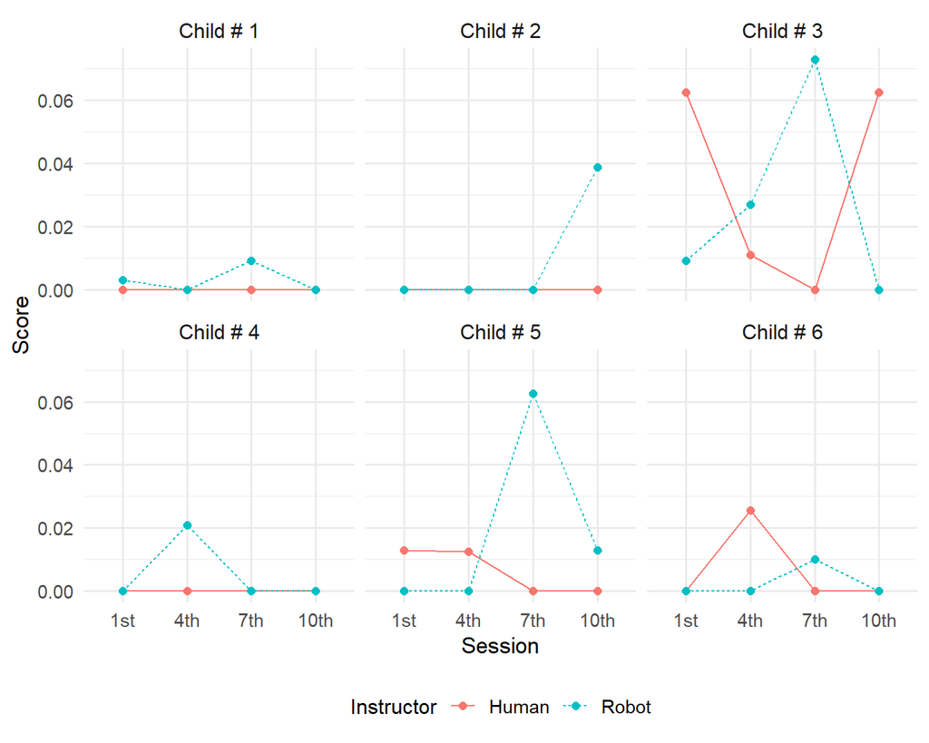

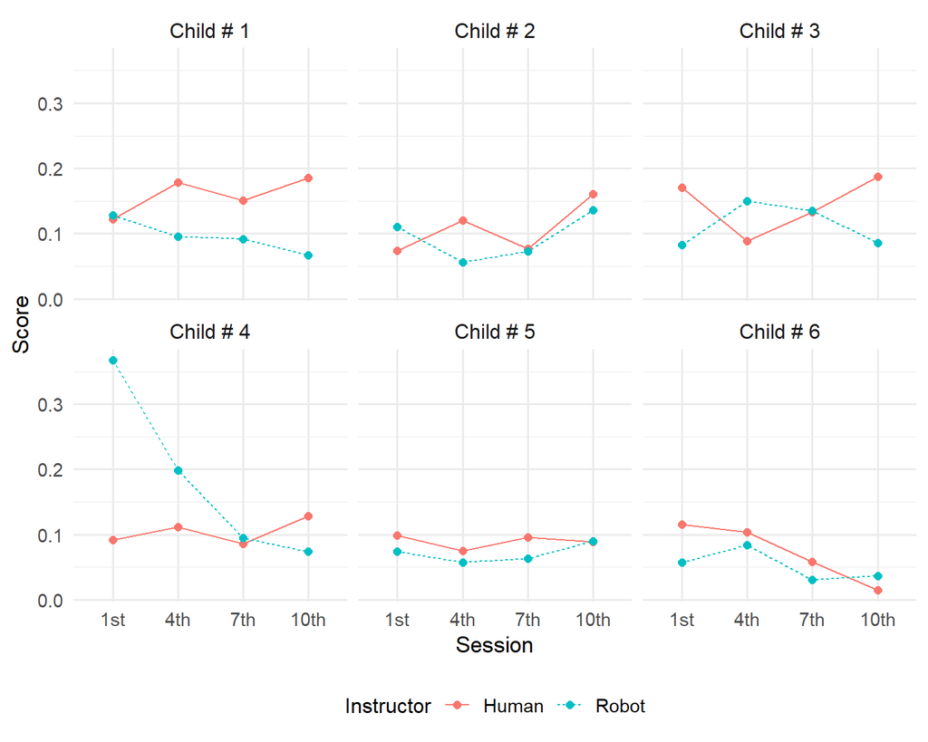

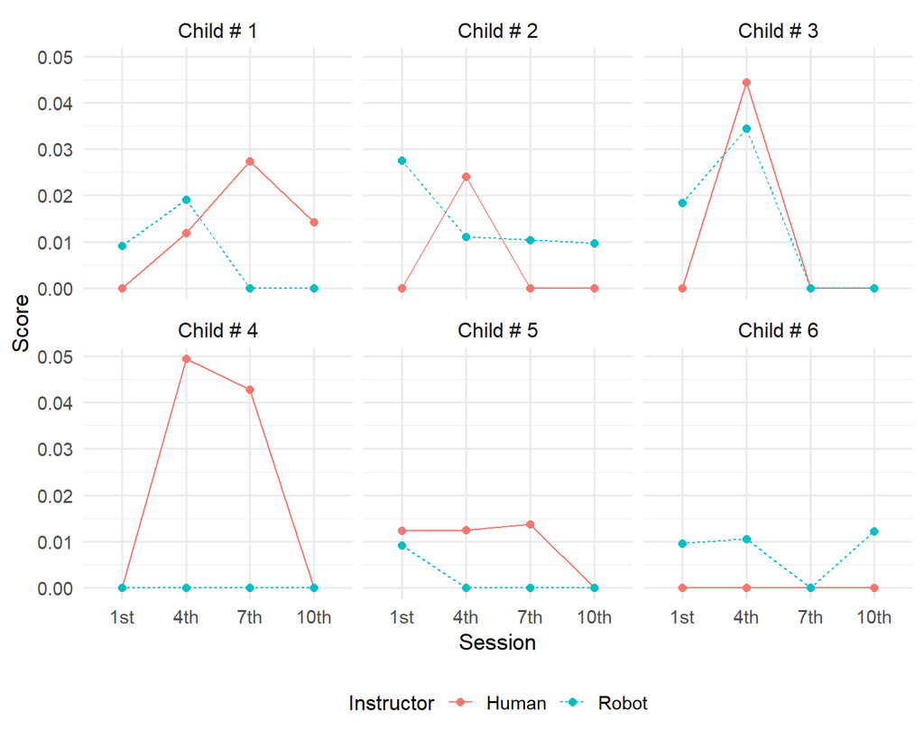

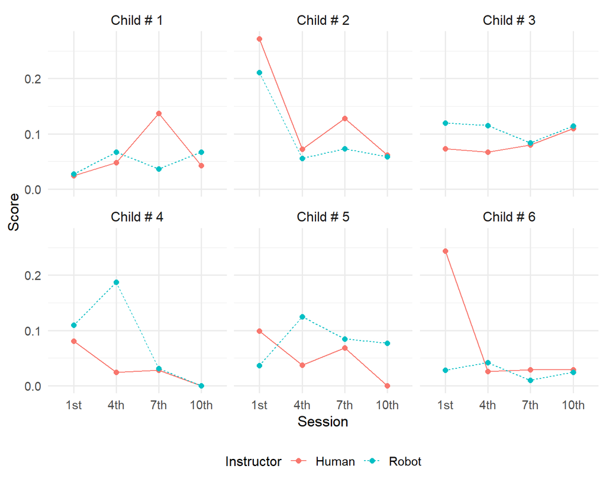

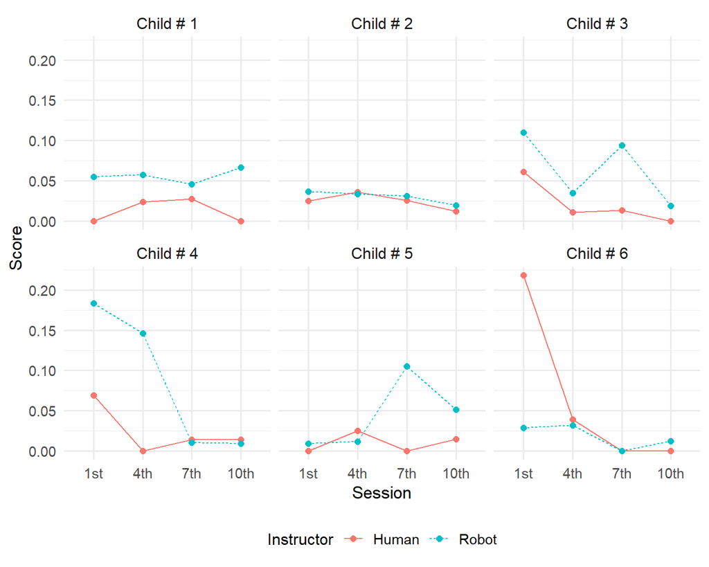

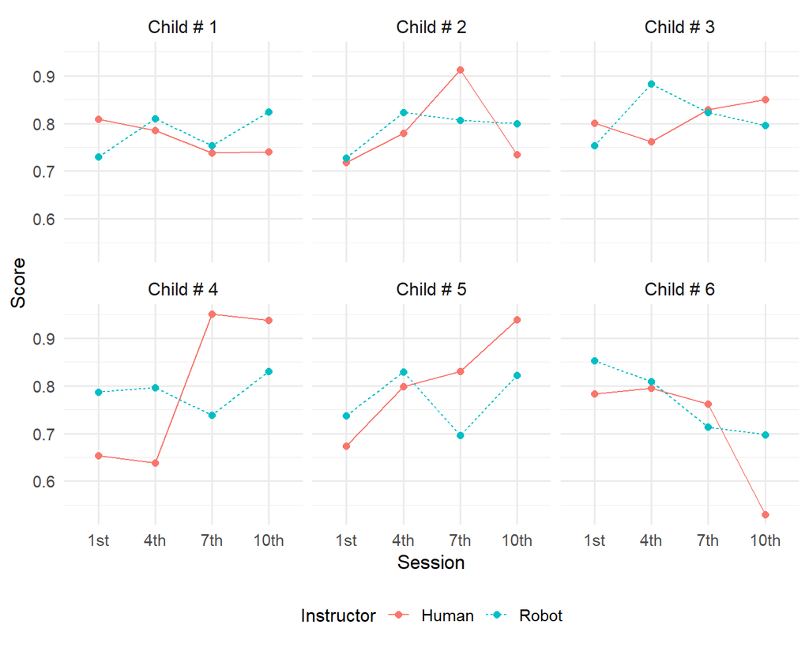

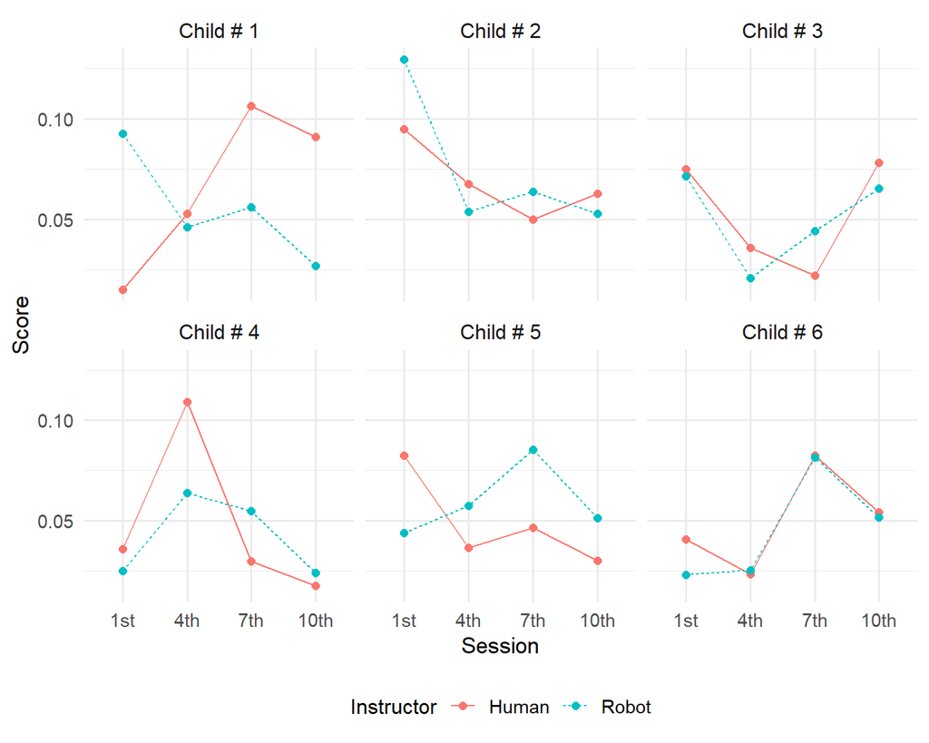

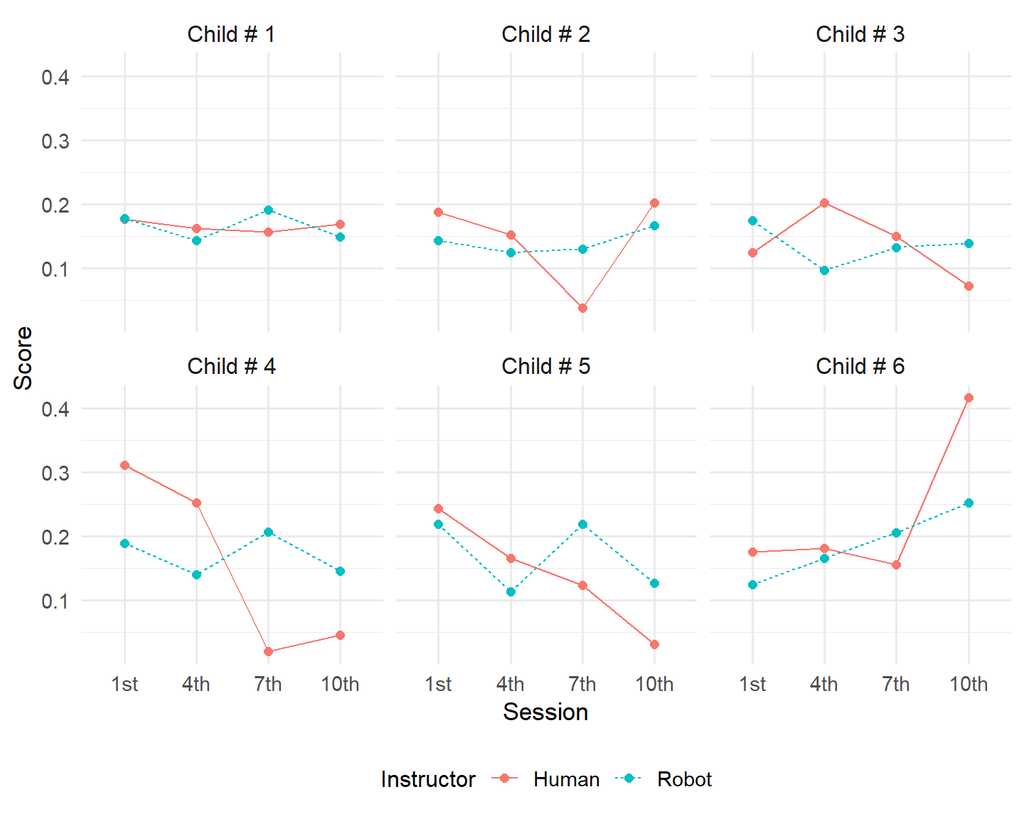

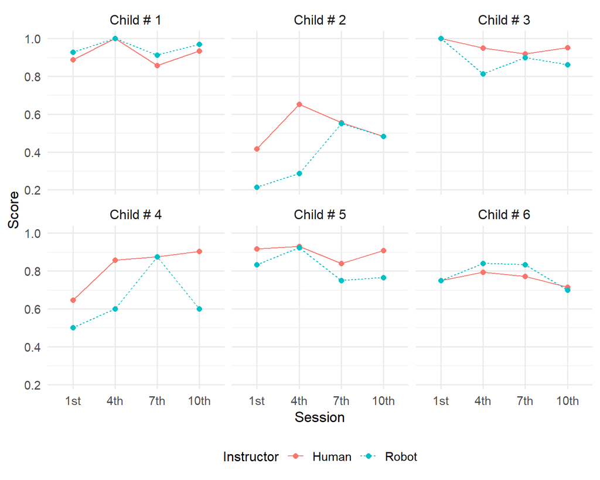

```r
library(ggplot2)
library(dplyr)
library(tidyr)
library(cowplot)

# Ensure output folder exists
if (!dir.exists("figures")) dir.create("figures")

# Load data
df <- read.csv("~/GitHub/Circle-Time-Data-Analyses/CircleTimeData-VBMAPP.csv")
df$Condition <- factor(df$Condition, levels = c(1, 2), labels = c("Human", "Robot"))
df$Subject <- paste("Child #", df$Subject, sep = " ")
df$Session <- factor(df$time, levels = c(1, 2, 3, 4), labels = c("1st", "4th", "7th", "10th"))

behavioral_vars <- c(
  "Affect_Positive", "Affect_Negative",
  "Communication_with_Instructor", "Communication_with_Instructor_Prompted",
  "Communication_with_Therapist", "Communication_with_Indeterminent",
  "Engagement_OnTarget", "Engagement_Therapist", "Engagement_OffTarget",
  "Performance_Positive"
)

# Loop through each behavior
for (var in behavioral_vars) {
  file_name <- paste0("figures/trajectories_", var, ".pdf")

  p <- ggplot(df, aes(x = Session, y = .data[[var]], color = Condition, linetype = Condition, group = Condition)) +
    geom_line() +
    geom_point(size = 2) +
    facet_wrap(~ Subject, ncol = 3) +
    labs(
      x = "Session",
      y = "Score",
      color = "Instructor",
      linetype = "Instructor"
    ) +
    theme_minimal(base_size = 13) +
    theme(
      strip.text = element_text(size = 12),
      axis.text = element_text(size = 11),
      legend.position = "bottom",          # ✅ Move legend under each plot
      legend.title = element_text(size = 12),
      legend.text = element_text(size = 11)
    )

  # Save to PDF
  ggsave(file_name, plot = p, width = 7.5, height = 6, device = "pdf")

  # Print to RMarkdown
  print(p)
}
```

### Affect

- **Positive Affect** was significantly higher during robot-led instruction compared to human-led instruction:  
  *β = 0.435, SE = 0.151, z = 2.89, p = 0.0039*  
  This suggests that children expressed more positive emotional behaviors (e.g., smiling, clapping) during robot sessions.
- **Negative Affect** did not differ significantly between conditions:  
  *β = 0.200, SE = 0.289, z = 0.69, p = 0.489*

### Communication

- **Communication with Instructor** showed no significant difference between conditions:  
  *β = -0.136, SE = 0.131, z = -1.04, p = 0.298*
- **Instructor-Prompted Communication** was also not significantly affected:  
  *β = 0.239, SE = 0.313, z = 0.76, p = 0.446*
- **Communication with Therapist or Peers** remained similar across conditions:  
  *β = 0.032, SE = 0.226, z = 0.14, p = 0.887*
- **Indeterminate Communication** (where the communication partner was unclear) was significantly higher under the robot condition:  
  *β = 1.05, SE = 0.294, z = 3.58, p = 0.0003*  
  This may reflect increased ambiguity in children’s social orientation during robot-led sessions.

### Engagement

- **On-Target Engagement** (attention to instructor or screen) did not differ significantly:  
  *β = -0.038, SE = 0.122, z = -0.32, p = 0.753*
- **Engagement with Therapist or Peers** showed no condition effect:  
  *β = 0.009, SE = 0.137, z = 0.06, p = 0.949*
- **Off-Target Engagement** (distraction or disengagement) also did not differ:  
  *β = 0.114, SE = 0.145, z = 0.79, p = 0.430*

### Performance

- **Positive Performance** was significantly lower in the robot condition:  
  *β = -0.374, SE = 0.161, z = -2.32, p = 0.020*  
  This indicates children demonstrated fewer correct task responses during robot-led sessions, after adjusting for time and VB-MAPP scores.

### Summary

In summary, the robot instructor was associated with **greater positive affect** but **lower task performance**. Communication directed to unknown partners was significantly more frequent in robot-led sessions, suggesting possible issues with clarity or focus. Engagement and most communication behaviors did not significantly differ between conditions. These findings highlight the **potential emotional benefits** of social robot instruction, while also identifying **critical areas—especially performance—that warrant refinement** in robot-mediated pedagogy.

## Interaction Effects: Moderator Influence of Time and VB-MAPP on Robot-Led Instruction

To explore whether the effect of robot-led instruction varied across time or with the learner’s developmental profile, we modeled interaction terms between `ConditionRobot` and two continuous covariates: `time_c` (centered session time) and `VBMAPP` (individual skill level). Below we interpret these moderation effects for each behavioral outcome.

### Affect

- **Positive Affect**
  - The interaction between `ConditionRobot` and `VBMAPP` was significant:  
    *β = 4.22, SE = 1.48, z = 2.86, p = 0.0043*  
    This suggests that the advantage of robot instruction in eliciting positive affect increased with higher VB-MAPP scores.
  - No significant moderation by time was observed:  
    *β = -0.070, SE = 0.121, z = -0.57, p = 0.566*
- **Negative Affect**
  - Neither time nor VB-MAPP significantly moderated the robot condition’s effect:  
    *Time interaction: β = 0.175, p = 0.485*  
    *VB-MAPP interaction: β = 0.110, p = 0.974*

### Engagement

- **On Target**
  - No significant moderation by VB-MAPP: *β = -0.534, p = 0.706*
  - Time showed a non-significant trend: *β = -0.162, p = 0.132*
- **With Therapist/Peers**
  - Neither moderator had a significant effect:  
    *Time: β = -0.022, p = 0.858*  
    *VB-MAPP: β = 0.137, p = 0.933*
- **Off Target**
  - Time significantly moderated the robot effect:  
    *β = 0.284, SE = 0.127, z = 2.24, p = 0.0250*  
    This implies that robot-led instruction was associated with increased off-target engagement as time progressed.
  - No significant interaction with VB-MAPP: *β = 0.461, p = 0.779*

### Performance

- **Positive Performance**
  - No significant moderation by either variable:  
    *Time: β = 0.019, p = 0.895*  
    *VB-MAPP: β = 0.606, p = 0.728*

### Summary of Interaction Effects

| Learning Behavior | VB-MAPP Moderation | Time Moderation | Interpretation |
| --- | --- | --- | --- |
| **Affect_Positive** | ✅ p = 0.0043 | ❌ | Robot effect stronger for children with higher VB-MAPP |
| **Affect_Negative** | ❌ | ❌ | No differential effect |
| **Comm._Instructor** | ❌ | ❌ | No moderation observed |
| **Comm._Prompted** | ✅ p = 0.0028 | ❌ | Fewer prompted responses from higher-skilled children under robot condition |
| **Comm._Therapist/Peers** | ❌ | ❌ | No differential effect |
| **Comm._Indeterminate** | ✅ p = 0.0168 | ❌ | More ambiguous social behaviors with robot, especially for higher VB-MAPP |
| **Engagement_OnTarget** | ❌ | ❌ (trend) | No clear pattern |
| **Engagement_Therapist/Peers** | ❌ | ❌ | No differential effect |
| **Engagement_OffTarget** | ❌ | ✅ p = 0.025 | Robot instruction led to more off-task behaviors over time |
| **Performance_Positive** | ❌ | ❌ | No significant moderation |

Overall, robot-led instruction was **more emotionally engaging for higher-performing children**, but it also led to **more ambiguous and off-task behaviors**, especially as sessions progressed. These nuanced findings underscore the importance of **personalizing robotic instruction** based on learner profile and session context.

## Predictive Role of Learning Behaviors on Performance in Human vs. Robot-Led Circle Time

### Overview

This section explores how various learning behaviors predict children’s **positive performance** during circle-time sessions, separately under **Human** and **Robot** instruction conditions. Using Generalized Linear Mixed Models (GLMMs) with beta regression, we analyzed each behavioral predictor while controlling for children’s VB-MAPP developmental levels and session time.

### Modeling Approach

For each learning behavior, we modeled:

```r
Performance_Positive ~ Behavior + VBMAPP + time_c + (1 | Subject)
```

```
## Performance_Positive ~ Behavior + VBMAPP + time_c + (1 | Subject)
```

```r
# Create time_c before subsetting
df$time_c <- scale(df$time, center = TRUE, scale = FALSE)

# Subset robot condition
robot_df <- df %>% filter(Condition == "Robot")

# ✅ Beta transformation for Performance_Positive
n <- nrow(robot_df)
robot_df$Performance_Positive <- (robot_df$Performance_Positive * (n - 1) + 0.5) / n

# Define predictors (excluding Performance variables)
predictors <- c(
  "Affect_Positive", "Affect_Negative",
  "Communication_with_Instructor", "Communication_with_Instructor_Prompted",
  "Communication_with_Therapist", "Communication_with_Indeterminent",
  "Engagement_OnTarget", "Engagement_Therapist", "Engagement_OffTarget"
)

# Response variable
response <- "Performance_Positive"

# Loop through predictors to model their effect on performance
for (pred in predictors) {
  cat("\n==============================\n")
  cat("Predictor:", pred, "=>", response, "\n")

  # Define formula
  form <- as.formula(paste(response, "~", pred, "+ VBMAPP + time_c + (1 | Subject)"))

  # Fit model
  model <- glmmTMB(form, data = robot_df, family = beta_family())

  # Tidy output
  results <- broom.mixed::tidy(model, effects = "fixed")
  results$stars <- sapply(results$p.value, sig_stars)

  # Display summary
  print(results[, c("term", "estimate", "std.error", "statistic", "p.value", "stars")])
}
```

```
##
## ==============================
## Predictor: Affect_Positive => Performance_Positive
## # A tibble: 4 × 6
##   term            estimate std.error statistic   p.value stars
##   <chr>              <dbl>     <dbl>     <dbl>     <dbl> <chr>
## 1 (Intercept)     -11.3        3.36     -3.37  0.000748  "***"
## 2 Affect_Positive  -2.92       2.08     -1.40  0.160     ""
## 3 VBMAPP            8.07       2.04      3.96  0.0000754 "***"
## 4 time_c           -0.0300     0.126    -0.238 0.812     ""
##
## ==============================
## Predictor: Affect_Negative => Performance_Positive
## # A tibble: 4 × 6
##   term            estimate std.error statistic p.value stars
##   <chr>              <dbl>     <dbl>     <dbl>   <dbl> <chr>
## 1 (Intercept)     -12.9        4.72     -2.73  0.00635 "**"
## 2 Affect_Negative  -4.02       7.46     -0.538 0.590   ""
## 3 VBMAPP            8.76       2.94      2.98  0.00287 "**"
## 4 time_c            0.0606     0.122     0.498 0.619   ""
##
## ==============================
## Predictor: Communication_with_Instructor => Performance_Positive
## # A tibble: 4 × 6
##   term                          estimate std.error statistic  p.value stars
##   <chr>                            <dbl>     <dbl>     <dbl>    <dbl> <chr>
## 1 (Intercept)                   -13.4        3.85     -3.48  0.000498 "***"
## 2 Communication_with_Instructor  -4.74       2.11     -2.25  0.0246   "*"
## 3 VBMAPP                          9.35       2.41      3.88  0.000104 "***"
## 4 time_c                         -0.0510     0.117    -0.437 0.662    ""
##
## ==============================
## Predictor: Communication_with_Instructor_Prompted => Performance_Positive
## # A tibble: 4 × 6
##   term                                estimate std.error statistic p.value stars
##   <chr>                                  <dbl>     <dbl>     <dbl>   <dbl> <chr>
## 1 (Intercept)                         -13.3        4.72     -2.82  0.00487 "**"
## 2 Communication_with_Instructor_Prom…   6.12      23.2       0.264 0.792   ""
## 3 VBMAPP                                8.96       2.90      3.09  0.00201 "**"
## 4 time_c                                0.0597     0.141     0.423 0.673   ""
```

[output cut: 35 more lines]

```
##   <chr>                   <dbl>     <dbl>     <dbl>   <dbl> <chr>
## 1 (Intercept)          -12.7        4.72     -2.69  0.00720 "**"
## 2 Engagement_Therapist  -0.750      5.31     -0.141 0.888   ""
## 3 VBMAPP                 8.64       2.90      2.98  0.00292 "**"
## 4 time_c                 0.0340     0.116     0.292 0.770   ""
##
## ==============================
## Predictor: Engagement_OffTarget => Performance_Positive
## # A tibble: 4 × 6
##   term                 estimate std.error statistic p.value stars
##   <chr>                   <dbl>     <dbl>     <dbl>   <dbl> <chr>
## 1 (Intercept)          -12.9        4.63     -2.79  0.00535 "**"
## 2 Engagement_OffTarget   0.820      3.68      0.223 0.824   ""
## 3 VBMAPP                 8.66       2.89      2.99  0.00275 "**"
## 4 time_c                 0.0352     0.114     0.310 0.756   ""
```

### How does each learning behavior predict performance under the human condition only?

```r
# Subset data to human-only condition
human_df <- df %>% filter(Condition == "Human")

# ✅ Beta-safe transformation of Performance_Positive
n_human <- nrow(human_df)
human_df$Performance_Positive <- (human_df$Performance_Positive * (n_human - 1) + 0.5) / n_human


# Define predictors (excluding Performance variables)
predictors <- c(
  "Affect_Positive", "Affect_Negative",
  "Communication_with_Instructor", "Communication_with_Instructor_Prompted",
  "Communication_with_Therapist", "Communication_with_Indeterminent",
  "Engagement_OnTarget", "Engagement_Therapist", "Engagement_OffTarget"
)

# Response variable
response <- "Performance_Positive"

# Loop through predictors to model their effect on performance
for (pred in predictors) {
  cat("\n==============================\n")
  cat("Predictor:", pred, "=>", response, "\n")

  # Define formula
  form <- as.formula(paste(response, "~", pred, "+ VBMAPP + time_c + (1 | Subject)"))

  # Fit model
  model <- glmmTMB(form, data = human_df, family = beta_family())

  # Tidy output
  results <- broom.mixed::tidy(model, effects = "fixed")
  results$stars <- sapply(results$p.value, sig_stars)

  # Display summary
  print(results[, c("term", "estimate", "std.error", "statistic", "p.value", "stars")])
}
```

```
##
## ==============================
## Predictor: Affect_Positive => Performance_Positive
## # A tibble: 4 × 6
##   term             estimate std.error statistic p.value stars
##   <chr>               <dbl>     <dbl>     <dbl>   <dbl> <chr>
## 1 (Intercept)     -11.5        4.41     -2.62   0.00882 "**"
## 2 Affect_Positive  -0.390      2.34     -0.166  0.868   ""
## 3 VBMAPP            8.17       2.63      3.11   0.00189 "**"
## 4 time_c            0.00174    0.0964    0.0181 0.986   ""
##
## ==============================
## Predictor: Affect_Negative => Performance_Positive
## # A tibble: 4 × 6
##   term            estimate std.error statistic  p.value stars
##   <chr>              <dbl>     <dbl>     <dbl>    <dbl> <chr>
## 1 (Intercept)     -11.3       1.76      -6.45  1.14e-10 "***"
## 2 Affect_Negative  21.3       8.22       2.60  9.42e- 3 "**"
## 3 VBMAPP            7.90      1.11       7.09  1.35e-12 "***"
## 4 time_c            0.0448    0.0933     0.480 6.31e- 1 ""
##
## ==============================
## Predictor: Communication_with_Instructor => Performance_Positive
## # A tibble: 4 × 6
##   term                           estimate std.error statistic     p.value stars
##   <chr>                             <dbl>     <dbl>     <dbl>       <dbl> <chr>
## 1 (Intercept)                   -11.9        2.38     -5.00   0.000000580 "***"
## 2 Communication_with_Instructor   5.72       2.57      2.23   0.0261      "*"
## 3 VBMAPP                          7.97       1.51      5.28   0.000000126 "***"
## 4 time_c                         -0.00378    0.0899   -0.0421 0.966       ""
##
## ==============================
## Predictor: Communication_with_Instructor_Prompted => Performance_Positive
## # A tibble: 4 × 6
##   term                                estimate std.error statistic p.value stars
##   <chr>                                  <dbl>     <dbl>     <dbl>   <dbl> <chr>
## 1 (Intercept)                         -11.8       3.34      -3.53  4.20e-4 "***"
## 2 Communication_with_Instructor_Prom…   5.96      7.73       0.771 4.40e-1 ""
## 3 VBMAPP                                8.27      2.09       3.96  7.61e-5 "***"
## 4 time_c                                0.0208    0.0876     0.237 8.12e-1 ""
```

[output cut: 35 more lines]

```
##   <chr>                    <dbl>     <dbl>     <dbl>     <dbl> <chr>
## 1 (Intercept)          -12.0        3.22     -3.72   0.000196  "***"
## 2 Engagement_Therapist  -0.553      4.01     -0.138  0.890     ""
## 3 VBMAPP                 8.44       1.99      4.24   0.0000221 "***"
## 4 time_c                 0.00517    0.0913    0.0566 0.955     ""
##
## ==============================
## Predictor: Engagement_OffTarget => Performance_Positive
## # A tibble: 4 × 6
##   term                 estimate std.error statistic    p.value stars
##   <chr>                   <dbl>     <dbl>     <dbl>      <dbl> <chr>
## 1 (Intercept)          -11.8       3.07      -3.82  0.000131   "***"
## 2 Engagement_OffTarget  -2.19      1.07      -2.05  0.0402     "*"
## 3 VBMAPP                 8.51      1.92       4.44  0.00000891 "***"
## 4 time_c                -0.0121    0.0825    -0.147 0.883      ""
```

### Summary of Results

#### Table 1. Predictive Effects of Learning Behaviors on Performance (Robot Condition)

[output not shown]

#### Interpretation – Robot Condition

- **Only one behavior**, `Communication_with_Instructor`, significantly predicted performance (*p* = 0.025). Interestingly, the relationship was **negative**, suggesting that more communication with the robot instructor might be linked to **lower** performance. This could be due to the child’s reliance on prompts or social behavior not aligning with task success.
- All other behaviors were not significantly predictive of performance in the robot-led sessions, indicating either weaker or non-existent associations in this context.

#### Table 2. Predictive Effects of Learning Behaviors on Performance (Human Condition)

[output not shown]

#### Interpretation – Human Condition

- **Affect_Negative** had a **strong positive association** with performance (*p* < 0.01). This counterintuitive finding may suggest that children expressing frustration or difficulty were **engaging with the task**, potentially improving with guidance.
- **Communication_with_Instructor** was also positively predictive (*p* = 0.026), contrasting with its negative effect under the robot condition. This may highlight the natural fluidity and effectiveness of human-led interactions.
- **Engagement_OffTarget** significantly predicted **lower** performance (*p* = 0.040), as expected.
- Marginal trends were observed for `Engagement_OnTarget` (*p* = 0.068) and `Communication_with_Therapist` (*p* = 0.080), suggesting potential relevance with larger samples.

### Comparative Insights

- **Communication_with_Instructor** showed opposite effects:
  - **Negative** under robot instruction (*p* = 0.025)
  - **Positive** under human instruction (*p* = 0.026)  
    This suggests that while human instructors likely foster meaningful instructional interactions, interactions with the robot may signal confusion, prompting, or a lack of task engagement.
- **Affect_Negative** was **positively predictive** of performance only under the **human** condition. This may reflect effective human responses to emotional cues, adjusting support to improve performance.
- None of the **Engagement metrics** significantly predicted performance in robot-led sessions. However, `Engagement_OffTarget` was **negatively associated** with performance under human instruction (*p* = 0.040), aligning with expectations.
- Across all models, **VB-MAPP score** was a **strong and consistent positive predictor** of performance (*p* < 0.01), validating the role of developmental ability.

# Conclusion

This study investigated the comparative efficacy of human- versus robot-led group instruction during Circle Time sessions for children with Autism Spectrum Disorder (ASD), using a within-subject longitudinal design. Behavioral data were analyzed across affect, communication, engagement, and task performance dimensions using generalized linear mixed models with beta regression.

Our findings demonstrate that robot-led instruction elicited significantly greater positive affect in children compared to human-led sessions, especially among participants with higher VB-MAPP scores. However, this affective advantage was not mirrored in performance outcomes; children exhibited significantly lower task performance under robot instruction. Notably, robot sessions were also associated with increased communication directed to indeterminate partners and more off-task engagement over time, suggesting possible challenges in maintaining instructional clarity and behavioral focus.

Behavioral predictors of performance diverged markedly between conditions. While communication with the human instructor positively predicted task success, the same behavior under robot instruction was negatively associated with performance—potentially reflecting less effective pedagogical interactions or misaligned social contingencies. Engagement metrics did not significantly predict performance under the robot condition, reinforcing the limited instructional efficacy of the robot in its current design.

These findings highlight the dual role of social robots as emotionally engaging but pedagogically limited agents in early autism interventions. The elevated positive affect may partly reflect a novelty effect, particularly among higher-functioning children, yet this affective engagement did not sustain or enhance learning outcomes. As such, future work should explore adaptive robot behaviors that integrate emotional responsiveness with task-contingent feedback and clearer instructional scaffolding. Designing robot-mediated group instruction that balances engagement with effectiveness is critical for supporting inclusive learning environments for neurodiverse populations.

```
##
## ====================
## Condition: Human | Predictor: Affect_Positive
## # A tibble: 4 × 6
##   term             estimate std.error statistic p.value stars
##   <chr>               <dbl>     <dbl>     <dbl>   <dbl> <chr>
## 1 (Intercept)     -11.5        4.41     -2.62   0.00882 "**"
## 2 Affect_Positive  -0.390      2.34     -0.166  0.868   ""
## 3 VBMAPP            8.17       2.63      3.11   0.00189 "**"
## 4 time_c            0.00174    0.0964    0.0181 0.986   ""
```

```
##
## ====================
## Condition: Human | Predictor: Affect_Negative
## # A tibble: 4 × 6
##   term            estimate std.error statistic  p.value stars
##   <chr>              <dbl>     <dbl>     <dbl>    <dbl> <chr>
## 1 (Intercept)     -11.3       1.76      -6.45  1.14e-10 "***"
## 2 Affect_Negative  21.3       8.22       2.60  9.42e- 3 "**"
## 3 VBMAPP            7.90      1.11       7.09  1.35e-12 "***"
## 4 time_c            0.0448    0.0933     0.480 6.31e- 1 ""
```

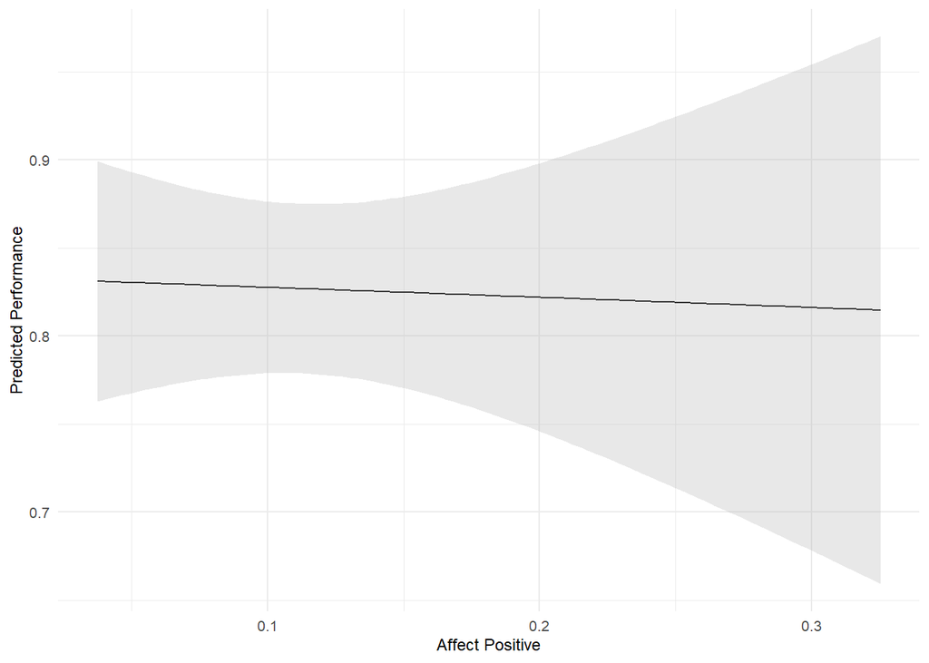

```
##
## ====================
## Condition: Human | Predictor: Communication_with_Instructor
## # A tibble: 4 × 6
##   term                           estimate std.error statistic     p.value stars
##   <chr>                             <dbl>     <dbl>     <dbl>       <dbl> <chr>
## 1 (Intercept)                   -11.9        2.38     -5.00   0.000000580 "***"
## 2 Communication_with_Instructor   5.72       2.57      2.23   0.0261      "*"
## 3 VBMAPP                          7.97       1.51      5.28   0.000000126 "***"
## 4 time_c                         -0.00378    0.0899   -0.0421 0.966       ""
```

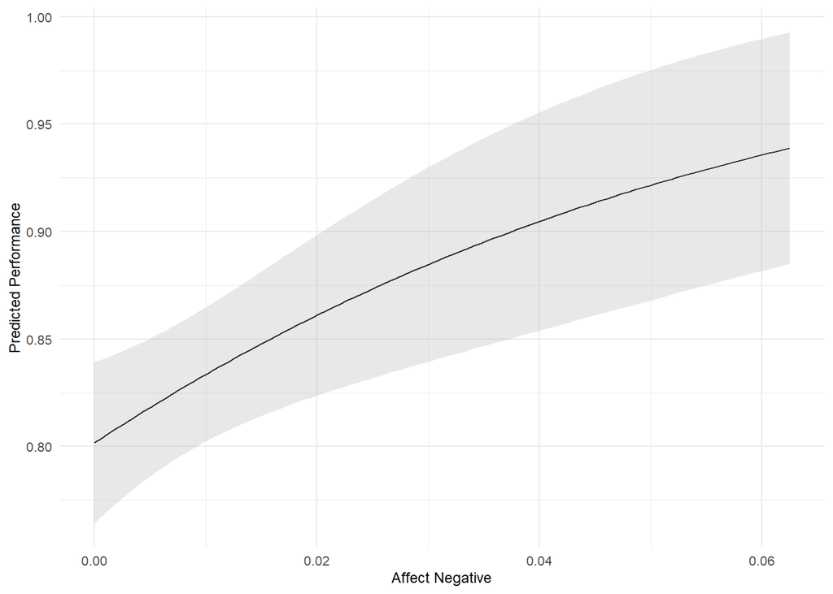

```
##
## ====================
## Condition: Human | Predictor: Communication_with_Instructor_Prompted
## # A tibble: 4 × 6
##   term                                estimate std.error statistic p.value stars
##   <chr>                                  <dbl>     <dbl>     <dbl>   <dbl> <chr>
## 1 (Intercept)                         -11.8       3.34      -3.53  4.20e-4 "***"
## 2 Communication_with_Instructor_Prom…   5.96      7.73       0.771 4.40e-1 ""
## 3 VBMAPP                                8.27      2.09       3.96  7.61e-5 "***"
## 4 time_c                                0.0208    0.0876     0.237 8.12e-1 ""
```

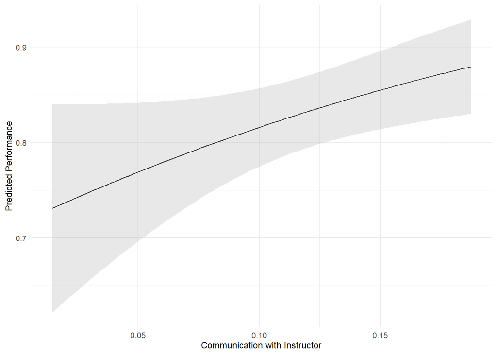

```
##
## ====================
## Condition: Human | Predictor: Communication_with_Therapist
## # A tibble: 4 × 6
##   term                         estimate std.error statistic  p.value stars
##   <chr>                           <dbl>     <dbl>     <dbl>    <dbl> <chr>
## 1 (Intercept)                  -10.3       3.59      -2.87  0.00416  "**"
## 2 Communication_with_Therapist  -2.90      1.66      -1.75  0.0808   "."
## 3 VBMAPP                         7.51      2.21       3.39  0.000699 "***"
## 4 time_c                        -0.0865    0.0997    -0.868 0.386    ""
```

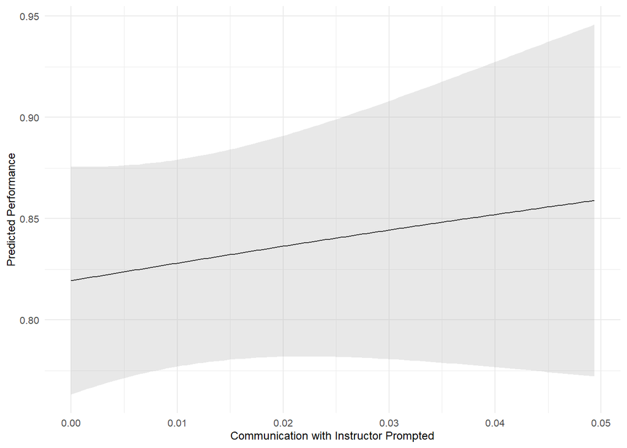

```
##
## ====================
## Condition: Human | Predictor: Communication_with_Indeterminent
## # A tibble: 4 × 6
##   term                              estimate std.error statistic   p.value stars
##   <chr>                                <dbl>     <dbl>     <dbl>     <dbl> <chr>
## 1 (Intercept)                      -12.0         3.16    -3.80   0.000143  "***"
## 2 Communication_with_Indeterminent  -0.220       2.58    -0.0855 0.932     ""
## 3 VBMAPP                             8.46        1.97     4.29   0.0000180 "***"
## 4 time_c                             0.00269     0.104    0.0258 0.979     ""
```

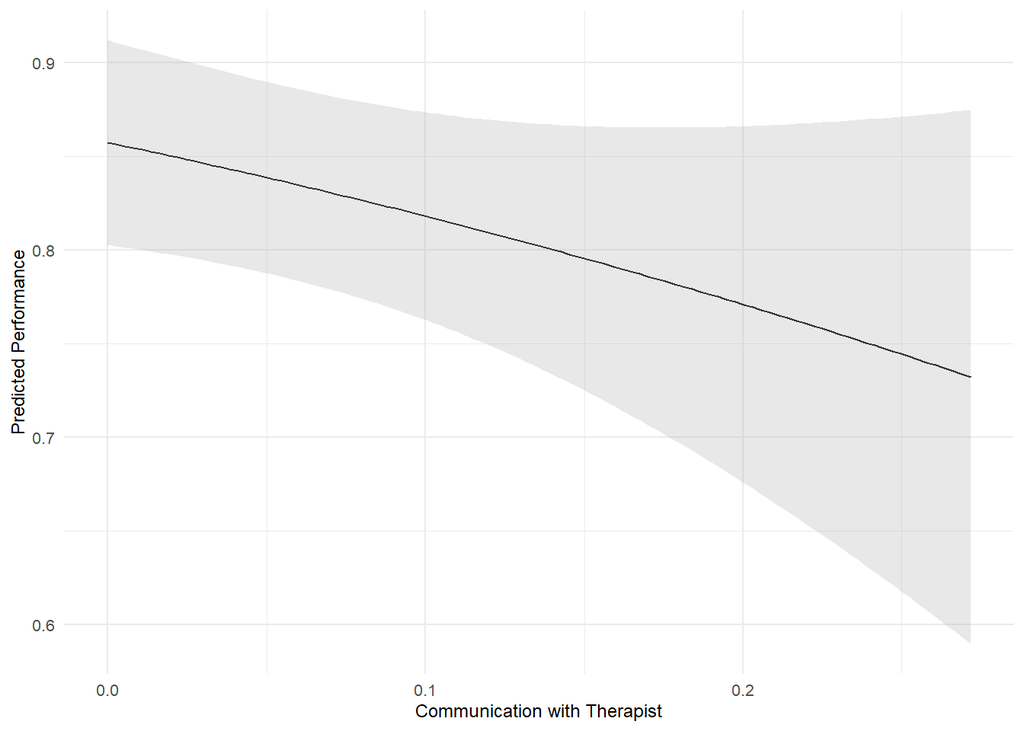

```
##
## ====================
## Condition: Human | Predictor: Engagement_OnTarget
## # A tibble: 4 × 6
##   term                estimate std.error statistic   p.value stars
##   <chr>                  <dbl>     <dbl>     <dbl>     <dbl> <chr>
## 1 (Intercept)         -13.3       3.17      -4.20  0.0000261 "***"
## 2 Engagement_OnTarget   1.77      0.970      1.82  0.0680    "."
## 3 VBMAPP                8.41      1.93       4.35  0.0000137 "***"
## 4 time_c               -0.0156    0.0842    -0.186 0.853     ""
```

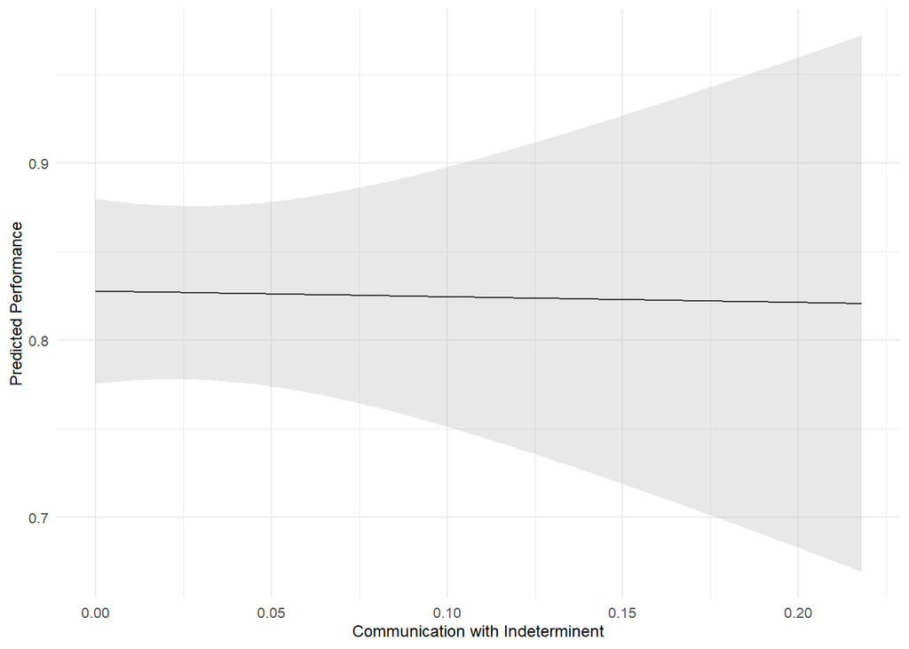

```
##
## ====================
## Condition: Human | Predictor: Engagement_Therapist
## # A tibble: 4 × 6
##   term                  estimate std.error statistic   p.value stars
##   <chr>                    <dbl>     <dbl>     <dbl>     <dbl> <chr>
## 1 (Intercept)          -12.0        3.22     -3.72   0.000196  "***"
## 2 Engagement_Therapist  -0.553      4.01     -0.138  0.890     ""
## 3 VBMAPP                 8.44       1.99      4.24   0.0000221 "***"
## 4 time_c                 0.00517    0.0913    0.0566 0.955     ""
```

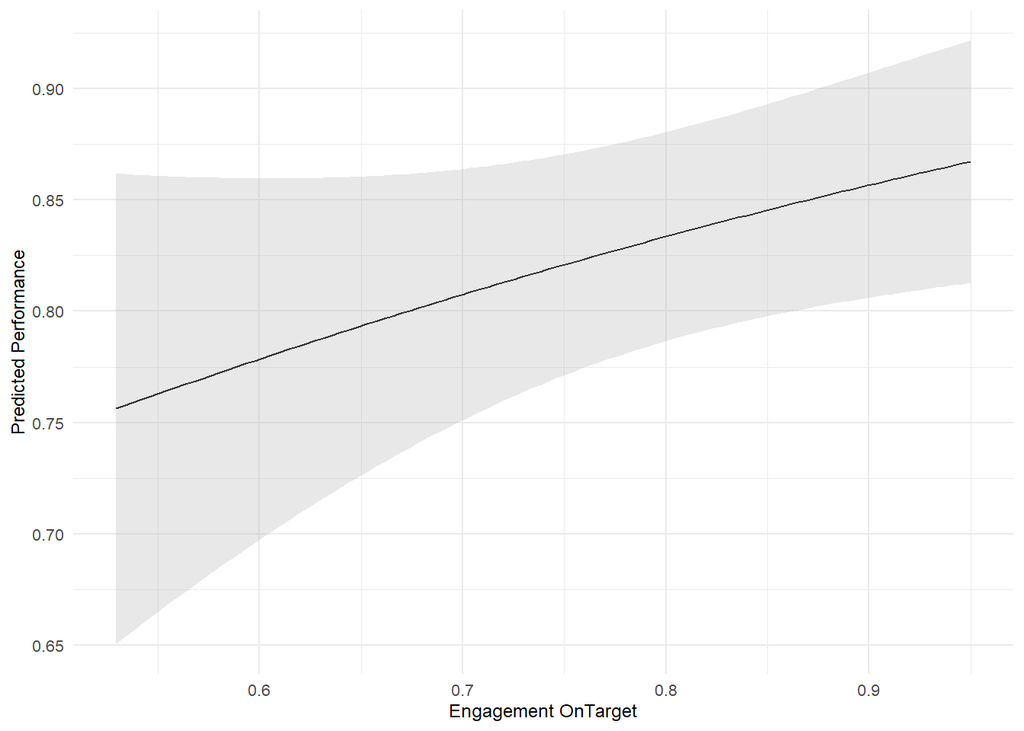

```
##
## ====================
## Condition: Human | Predictor: Engagement_OffTarget
## # A tibble: 4 × 6
##   term                 estimate std.error statistic    p.value stars
##   <chr>                   <dbl>     <dbl>     <dbl>      <dbl> <chr>
## 1 (Intercept)          -11.8       3.07      -3.82  0.000131   "***"
## 2 Engagement_OffTarget  -2.19      1.07      -2.05  0.0402     "*"
## 3 VBMAPP                 8.51      1.92       4.44  0.00000891 "***"
## 4 time_c                -0.0121    0.0825    -0.147 0.883      ""
```

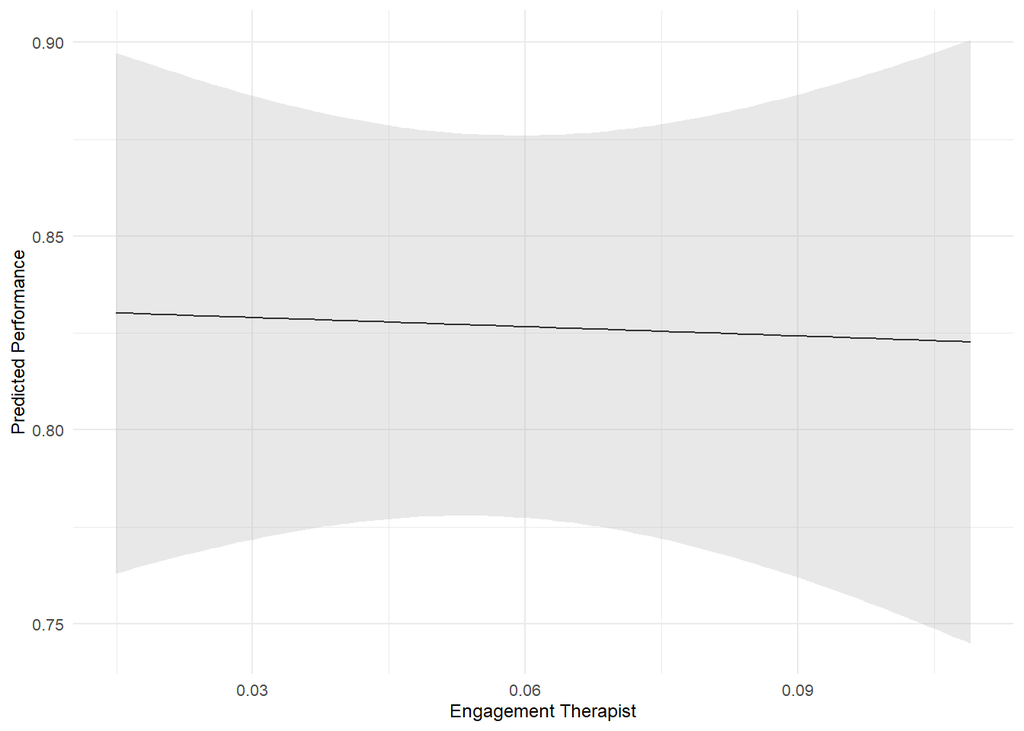

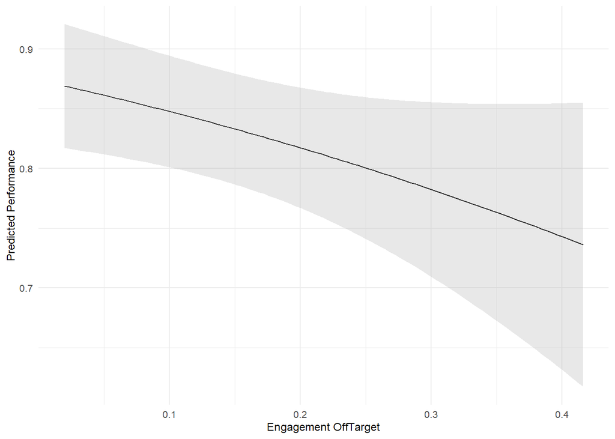

```r
library(glmmTMB)
library(broom.mixed)
library(ggplot2)
library(dplyr)

# Make sure figures directory exists
if (!dir.exists("figs")) dir.create("figs")

# Add centered time variable
df$time_c <- scale(df$time, center = TRUE, scale = FALSE)

# Define response and predictors
response <- "Performance_Positive"
predictors <- c(
  "Affect_Positive", "Affect_Negative",
  "Communication_with_Instructor", "Communication_with_Instructor_Prompted",
  "Communication_with_Therapist", "Communication_with_Indeterminent",
  "Engagement_OnTarget", "Engagement_Therapist", "Engagement_OffTarget"
)

# Define a function to add significance stars
sig_stars <- function(p) {
  if (is.na(p)) return("")
  if (p < 0.001) return("***")
  else if (p < 0.01) return("**")
  else if (p < 0.05) return("*")
  else if (p < 0.1) return(".")
  else return("")
}

# Function to model and plot per condition
analyze_condition <- function(df_cond, cond_label) {
  # Beta transformation of response
  n <- nrow(df_cond)
  df_cond[[response]] <- (df_cond[[response]] * (n - 1) + 0.5) / n

  for (pred in predictors) {
    form <- as.formula(paste(response, "~", pred, "+ VBMAPP + time_c + (1 | Subject)"))
    model <- glmmTMB(form, data = df_cond, family = beta_family())
    results <- broom.mixed::tidy(model, effects = "fixed")
    results$stars <- sapply(results$p.value, sig_stars)

    cat("\n====================\n")
    cat("Condition:", cond_label, "| Predictor:", pred, "\n")
    print(results[, c("term", "estimate", "std.error", "statistic", "p.value", "stars")])

    # Generate predictions for plotting
    new_data <- expand.grid(
      pred_val = seq(min(df_cond[[pred]], na.rm = TRUE), max(df_cond[[pred]], na.rm = TRUE), length.out = 100),
      VBMAPP = mean(df_cond$VBMAPP, na.rm = TRUE),
      time_c = 0,
      Subject = NA
    )
    colnames(new_data)[1] <- pred

    preds <- predict(model, newdata = new_data, type = "response", se.fit = TRUE)
    new_data$predicted <- preds$fit
    new_data$lower <- preds$fit - 1.96 * preds$se.fit
    new_data$upper <- preds$fit + 1.96 * preds$se.fit

    # Create plot
    p <- ggplot(new_data, aes_string(x = pred, y = "predicted")) +
      geom_line(color = "black") +
      geom_ribbon(aes(ymin = lower, ymax = upper), fill = "gray70", alpha = 0.3) +
      labs(
        x = gsub("_", " ", pred),
        y = "Predicted Performance"
      ) +
      theme_minimal(base_size = 10) +
      theme(
        plot.title = element_blank(),
        axis.title = element_text(size = 9),
        axis.text = element_text(size = 8),
        legend.position = "none"
      )

    # Save to PDF
    pdf_file <- paste0("figs/predictor_", pred, "_", cond_label, ".pdf")
    ggsave(pdf_file, plot = p, width = 6, height = 4)

    # Print inline
    print(p)
  }
}

# Run analysis separately for Human and Robot
analyze_condition(df %>% filter(Condition == "Human"), "Human")
```

```r
analyze_condition(df %>% filter(Condition == "Robot"), "Robot")
```

```
##
## ====================
## Condition: Robot | Predictor: Affect_Positive
## # A tibble: 4 × 6
##   term            estimate std.error statistic   p.value stars
##   <chr>              <dbl>     <dbl>     <dbl>     <dbl> <chr>
## 1 (Intercept)     -11.3        3.36     -3.37  0.000748  "***"
## 2 Affect_Positive  -2.92       2.08     -1.40  0.160     ""
## 3 VBMAPP            8.07       2.04      3.96  0.0000754 "***"
## 4 time_c           -0.0300     0.126    -0.238 0.812     ""
```

```
##
## ====================
## Condition: Robot | Predictor: Affect_Negative
## # A tibble: 4 × 6
##   term            estimate std.error statistic p.value stars
##   <chr>              <dbl>     <dbl>     <dbl>   <dbl> <chr>
## 1 (Intercept)     -12.9        4.72     -2.73  0.00635 "**"
## 2 Affect_Negative  -4.02       7.46     -0.538 0.590   ""
## 3 VBMAPP            8.76       2.94      2.98  0.00287 "**"
## 4 time_c            0.0606     0.122     0.498 0.619   ""
```

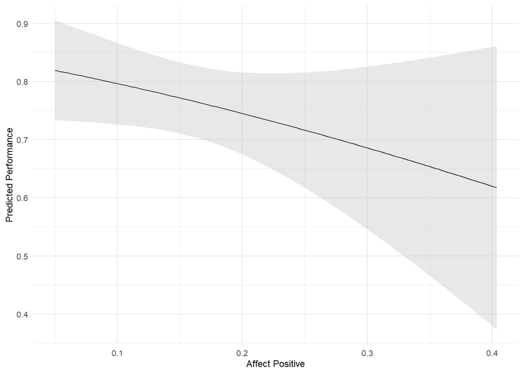

```
##
## ====================
## Condition: Robot | Predictor: Communication_with_Instructor
## # A tibble: 4 × 6
##   term                          estimate std.error statistic  p.value stars
##   <chr>                            <dbl>     <dbl>     <dbl>    <dbl> <chr>
## 1 (Intercept)                   -13.4        3.85     -3.48  0.000498 "***"
## 2 Communication_with_Instructor  -4.74       2.11     -2.25  0.0246   "*"
## 3 VBMAPP                          9.35       2.41      3.88  0.000104 "***"
## 4 time_c                         -0.0510     0.117    -0.437 0.662    ""
```

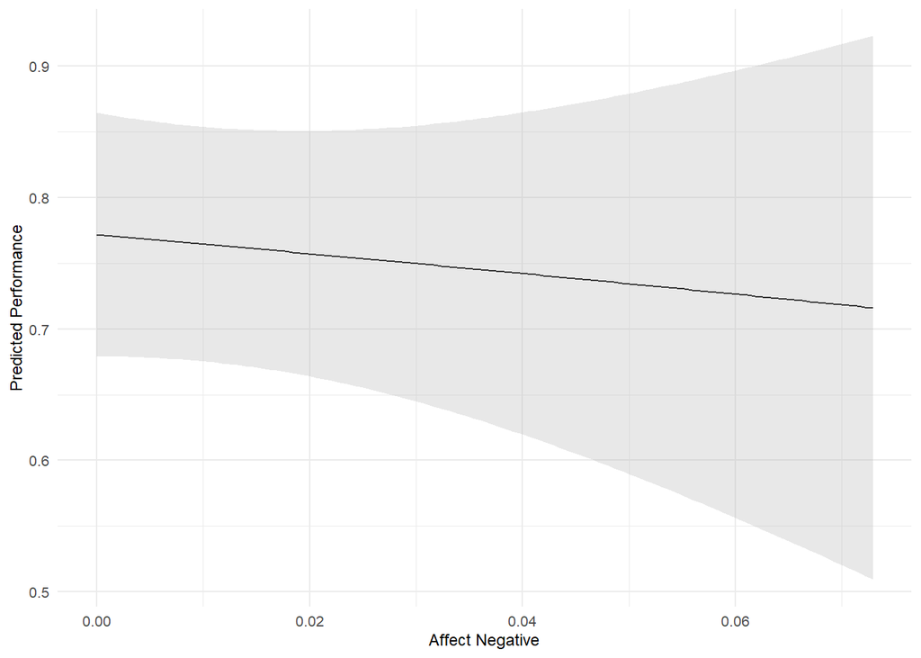

```
##
## ====================
## Condition: Robot | Predictor: Communication_with_Instructor_Prompted
## # A tibble: 4 × 6
##   term                                estimate std.error statistic p.value stars
##   <chr>                                  <dbl>     <dbl>     <dbl>   <dbl> <chr>
## 1 (Intercept)                         -13.3        4.72     -2.82  0.00487 "**"
## 2 Communication_with_Instructor_Prom…   6.12      23.2       0.264 0.792   ""
## 3 VBMAPP                                8.96       2.90      3.09  0.00201 "**"
## 4 time_c                                0.0597     0.141     0.423 0.673   ""
```

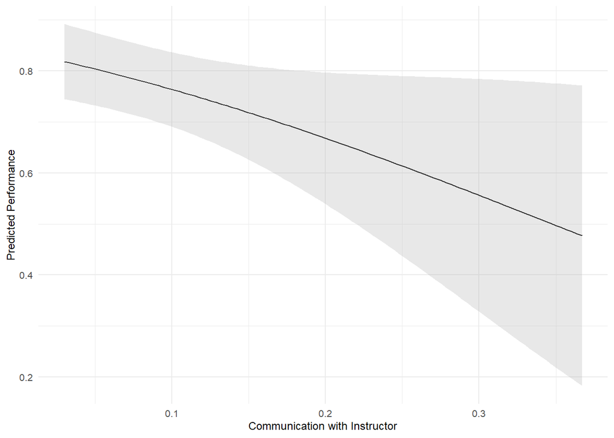

```
##
## ====================
## Condition: Robot | Predictor: Communication_with_Therapist
## # A tibble: 4 × 6
##   term                         estimate std.error statistic p.value stars
##   <chr>                           <dbl>     <dbl>     <dbl>   <dbl> <chr>
## 1 (Intercept)                  -12.3        4.56     -2.69  0.00713 "**"
## 2 Communication_with_Therapist  -3.46       2.72     -1.27  0.202   ""
## 3 VBMAPP                         8.53       2.83      3.01  0.00260 "**"
## 4 time_c                        -0.0290     0.123    -0.236 0.813   ""
```

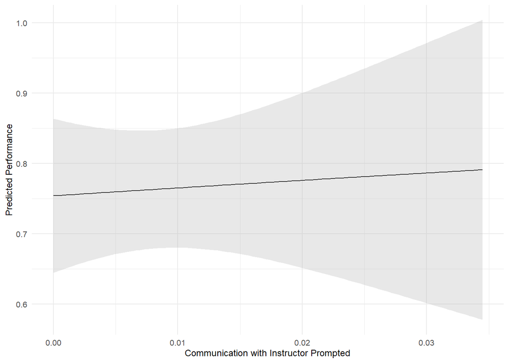

```
##
## ====================
## Condition: Robot | Predictor: Communication_with_Indeterminent
## # A tibble: 4 × 6
##   term                             estimate std.error statistic p.value stars
##   <chr>                               <dbl>     <dbl>     <dbl>   <dbl> <chr>
## 1 (Intercept)                      -13.8        4.64     -2.98  0.00285 "**"
## 2 Communication_with_Indeterminent  -4.40       3.08     -1.43  0.153   ""
## 3 VBMAPP                             9.48       2.91      3.26  0.00111 "**"
## 4 time_c                            -0.0265     0.118    -0.224 0.823   ""
```

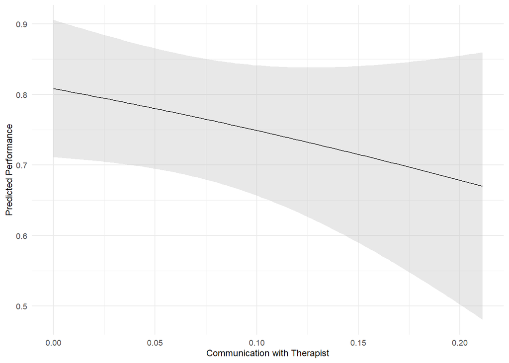

```
##
## ====================
## Condition: Robot | Predictor: Engagement_OnTarget
## # A tibble: 4 × 6
##   term                estimate std.error statistic p.value stars
##   <chr>                  <dbl>     <dbl>     <dbl>   <dbl> <chr>
## 1 (Intercept)         -12.8        5.03    -2.54   0.0110  "*"
## 2 Engagement_OnTarget  -0.0813     2.62    -0.0310 0.975   ""
## 3 VBMAPP                8.71       2.86     3.05   0.00231 "**"
## 4 time_c                0.0381     0.113    0.336  0.737   ""
```

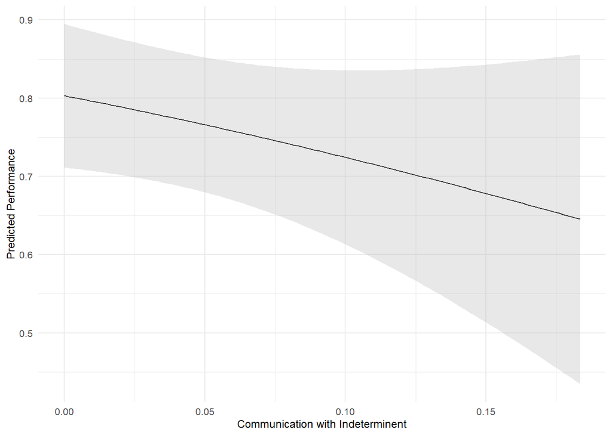

```
##
## ====================
## Condition: Robot | Predictor: Engagement_Therapist
## # A tibble: 4 × 6
##   term                 estimate std.error statistic p.value stars
##   <chr>                   <dbl>     <dbl>     <dbl>   <dbl> <chr>
## 1 (Intercept)          -12.7        4.72     -2.69  0.00720 "**"
## 2 Engagement_Therapist  -0.750      5.31     -0.141 0.888   ""
## 3 VBMAPP                 8.64       2.90      2.98  0.00292 "**"
## 4 time_c                 0.0340     0.116     0.292 0.770   ""
```

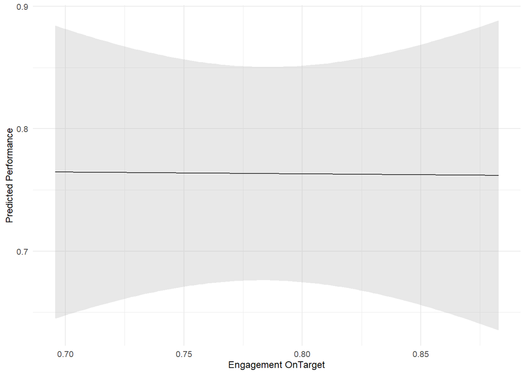

```
##
## ====================
## Condition: Robot | Predictor: Engagement_OffTarget
## # A tibble: 4 × 6
##   term                 estimate std.error statistic p.value stars
##   <chr>                   <dbl>     <dbl>     <dbl>   <dbl> <chr>
## 1 (Intercept)          -12.9        4.63     -2.79  0.00535 "**"
## 2 Engagement_OffTarget   0.820      3.68      0.223 0.824   ""
## 3 VBMAPP                 8.66       2.89      2.99  0.00275 "**"
## 4 time_c                 0.0352     0.114     0.310 0.756   ""
```

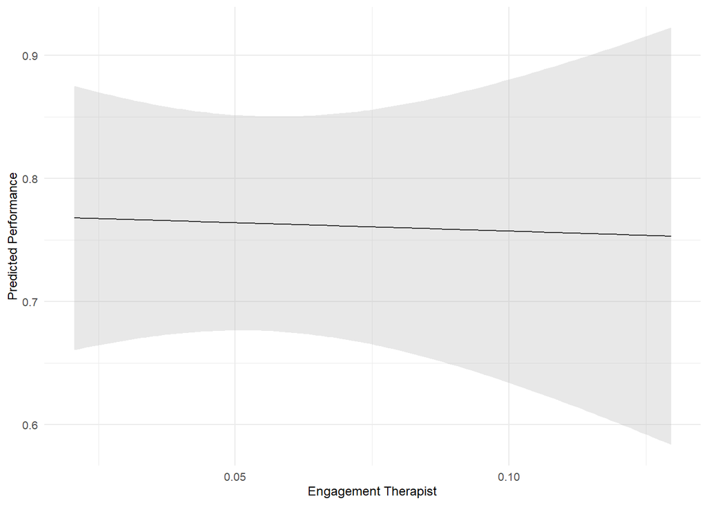

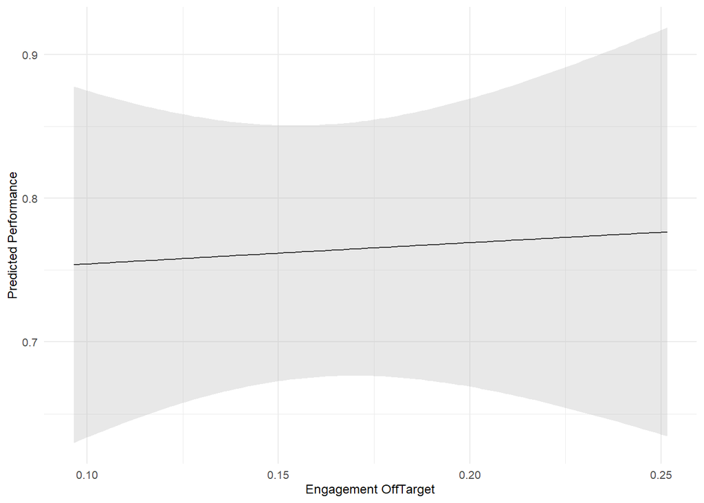

```
##
## ====================
## Predictor: Affect_Positive
## # A tibble: 6 × 6
##   term                            estimate std.error statistic  p.value stars
##   <chr>                              <dbl>     <dbl>     <dbl>    <dbl> <chr>
## 1 (Intercept)                    -12.5        3.98     -3.15   0.00165  "**"
## 2 Affect_Positive                 -0.0783     1.76     -0.0444 0.965    ""
## 3 ConditionRobot                   0.0551     0.348     0.158  0.874    ""
## 4 VBMAPP                           8.78       2.43      3.61   0.000309 "***"
## 5 time_c                          -0.00640    0.0807   -0.0793 0.937    ""
## 6 Affect_Positive:ConditionRobot  -2.30       1.96     -1.17   0.240    ""
```

```
##
## ====================
## Predictor: Affect_Negative
## # A tibble: 6 × 6
##   term                           estimate std.error statistic  p.value stars
##   <chr>                             <dbl>     <dbl>     <dbl>    <dbl> <chr>
## 1 (Intercept)                    -12.8       4.03      -3.16  0.00157  "**"
## 2 Affect_Negative                 11.1       9.98       1.12  0.264    ""
## 3 ConditionRobot                  -0.257     0.188     -1.37  0.171    ""
## 4 VBMAPP                           8.89      2.51       3.54  0.000404 "***"
## 5 time_c                           0.0524    0.0811     0.646 0.518    ""
## 6 Affect_Negative:ConditionRobot -16.2      11.3       -1.43  0.153    ""
```

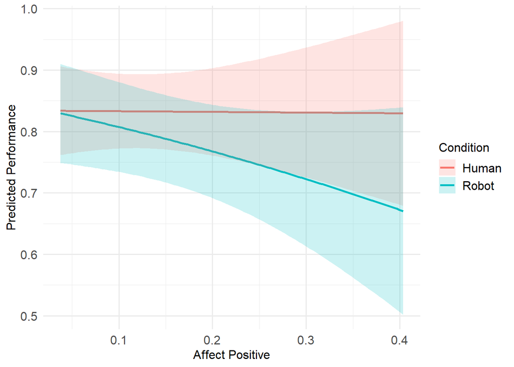

```
##
## ====================
## Predictor: Communication_with_Instructor
## # A tibble: 6 × 6
##   term                                estimate std.error statistic p.value stars
##   <chr>                                  <dbl>     <dbl>     <dbl>   <dbl> <chr>
## 1 (Intercept)                         -13.6       3.69      -3.69  2.20e-4 "***"
## 2 Communication_with_Instructor         3.53      3.13       1.13  2.59e-1 ""
## 3 ConditionRobot                        0.455     0.405      1.12  2.61e-1 ""
## 4 VBMAPP                                9.24      2.30       4.03  5.68e-5 "***"
## 5 time_c                               -0.0253    0.0767    -0.330 7.42e-1 ""
## 6 Communication_with_Instructor:Cond…  -8.13      3.49      -2.33  1.99e-2 "*"
```

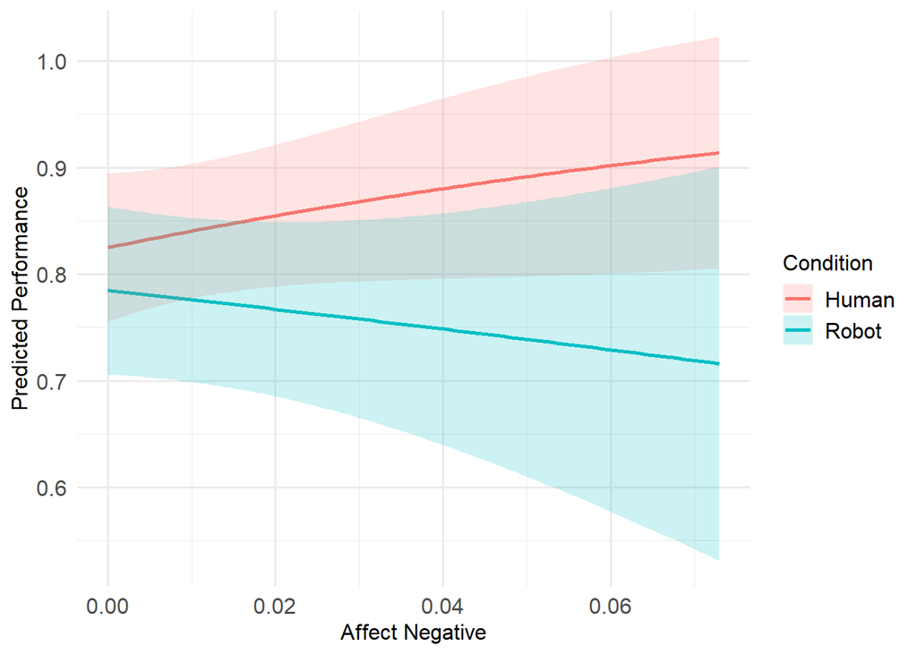

```
##
## ====================
## Predictor: Communication_with_Instructor_Prompted
## # A tibble: 6 × 6
##   term                                estimate std.error statistic p.value stars
##   <chr>                                  <dbl>     <dbl>     <dbl>   <dbl> <chr>
## 1 (Intercept)                         -12.7       4.48      -2.84  0.00450 "**"
## 2 Communication_with_Instructor_Prom…   9.73      8.98       1.08  0.279   ""
## 3 ConditionRobot                       -0.300     0.228     -1.32  0.187   ""
## 4 VBMAPP                                8.87      2.79       3.18  0.00147 "**"
## 5 time_c                                0.0393    0.0804     0.489 0.625   ""
## 6 Communication_with_Instructor_Prom…  -8.81     18.9       -0.467 0.641   ""
```

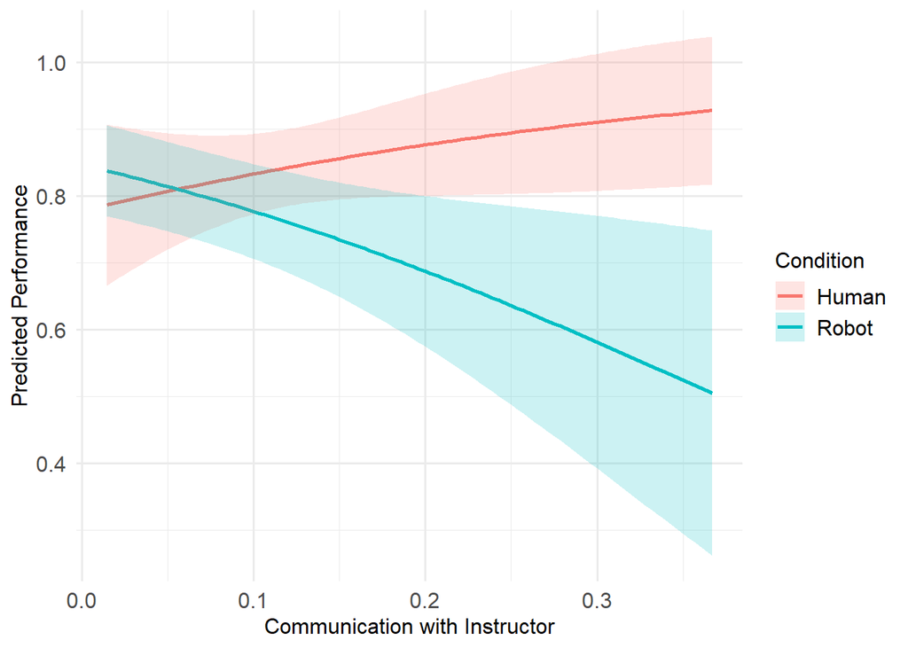

```
##
## ====================
## Predictor: Communication_with_Therapist
## # A tibble: 6 × 6
##   term                                estimate std.error statistic p.value stars
##   <chr>                                  <dbl>     <dbl>     <dbl>   <dbl> <chr>
## 1 (Intercept)                         -11.7       4.53      -2.59  0.00970 "**"
## 2 Communication_with_Therapist         -2.88      1.80      -1.60  0.110   ""
## 3 ConditionRobot                       -0.237     0.267     -0.885 0.376   ""
## 4 VBMAPP                                8.44      2.81       3.01  0.00264 "**"
## 5 time_c                               -0.0735    0.0849    -0.866 0.387   ""
## 6 Communication_with_Therapist:Condi…  -2.04      2.65      -0.769 0.442   ""
```

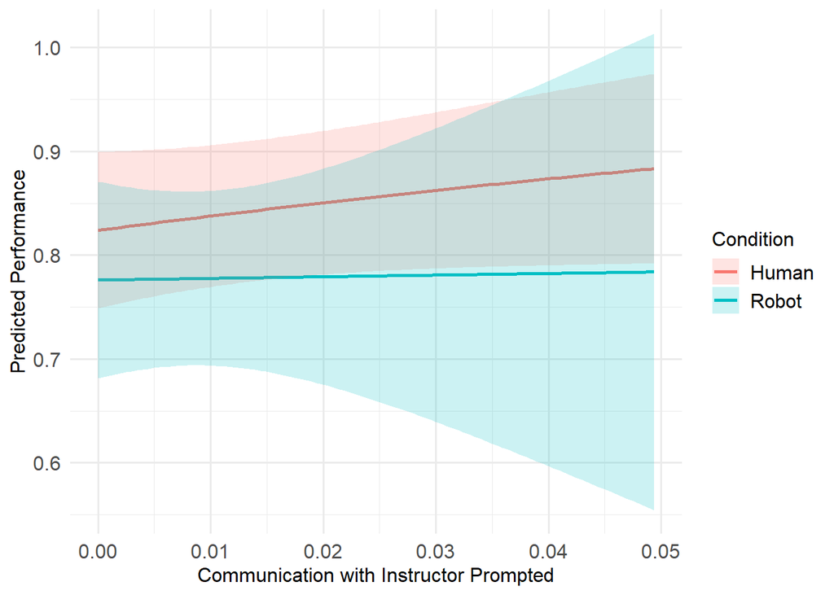

```
##
## ====================
## Predictor: Communication_with_Indeterminent
## # A tibble: 6 × 6
##   term                                estimate std.error statistic p.value stars
##   <chr>                                  <dbl>     <dbl>     <dbl>   <dbl> <chr>
## 1 (Intercept)                         -13.5       4.43      -3.05  2.32e-3 "**"
## 2 Communication_with_Indeterminent     -1.04      2.81      -0.369 7.12e-1 ""
## 3 ConditionRobot                       -0.186     0.228     -0.813 4.16e-1 ""
## 4 VBMAPP                                9.43      2.76       3.42  6.22e-4 "***"
## 5 time_c                               -0.0186    0.0821    -0.227 8.21e-1 ""
## 6 Communication_with_Indeterminent:C…  -3.73      3.77      -0.988 3.23e-1 ""
```

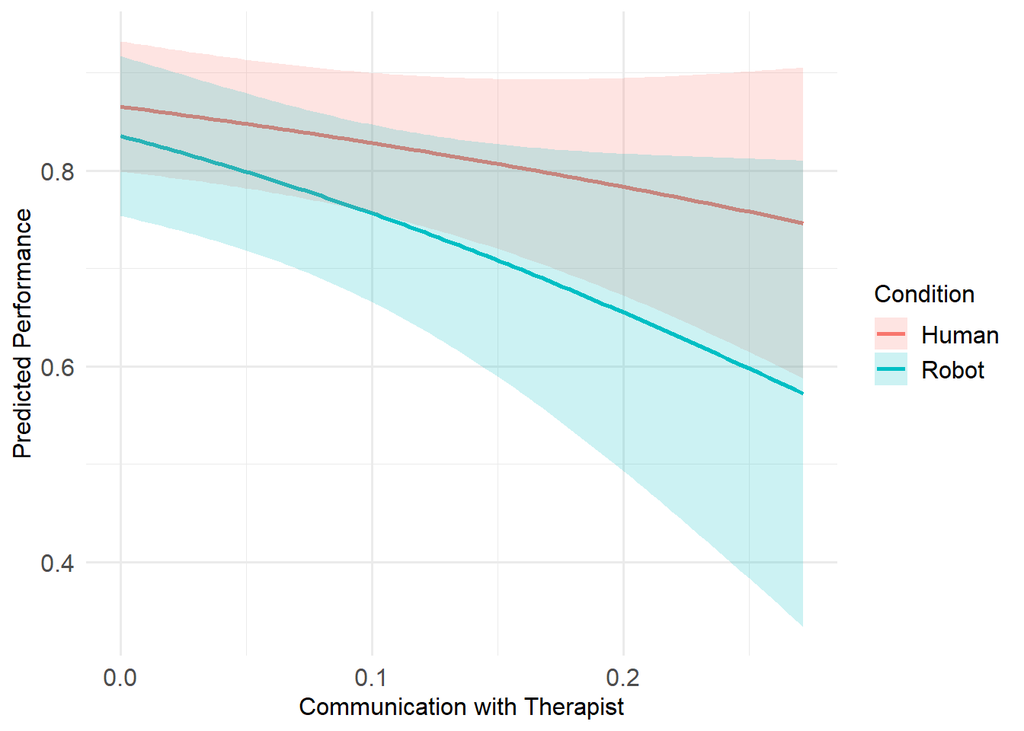

```
##
## ====================
## Predictor: Engagement_OnTarget
## # A tibble: 6 × 6
##   term                                estimate std.error statistic p.value stars
##   <chr>                                  <dbl>     <dbl>     <dbl>   <dbl> <chr>
## 1 (Intercept)                        -14.3        4.39     -3.27   1.09e-3 "**"
## 2 Engagement_OnTarget                  1.98       1.19      1.67   9.56e-2 "."
## 3 ConditionRobot                       1.38       2.05      0.674  5.00e-1 ""
## 4 VBMAPP                               8.98       2.68      3.35   7.95e-4 "***"
## 5 time_c                               0.00293    0.0764    0.0383 9.69e-1 ""
## 6 Engagement_OnTarget:ConditionRobot  -2.27       2.62     -0.867  3.86e-1 ""
```

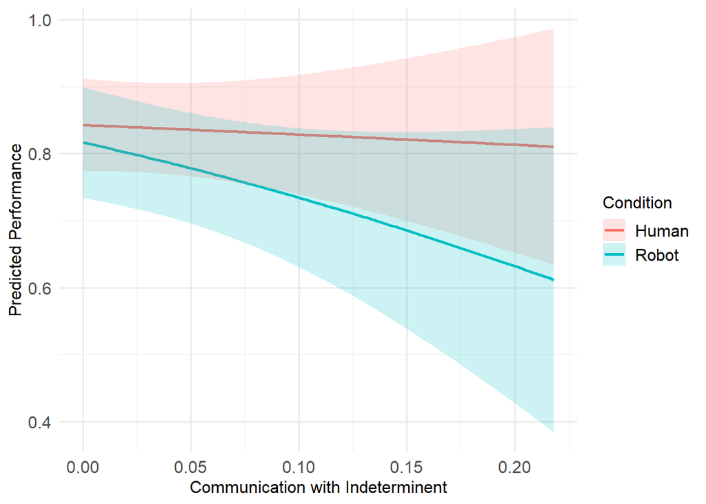

```
##
## ====================
## Predictor: Engagement_Therapist
## # A tibble: 6 × 6
##   term                                estimate std.error statistic p.value stars
##   <chr>                                  <dbl>     <dbl>     <dbl>   <dbl> <chr>
## 1 (Intercept)                         -12.6       4.32      -2.92  3.46e-3 "**"
## 2 Engagement_Therapist                 -0.581     4.90      -0.119 9.06e-1 ""
## 3 ConditionRobot                       -0.307     0.406     -0.755 4.50e-1 ""
## 4 VBMAPP                                8.88      2.67       3.32  8.89e-4 "***"
## 5 time_c                                0.0195    0.0809     0.242 8.09e-1 ""
## 6 Engagement_Therapist:ConditionRobot  -1.27      6.41      -0.198 8.43e-1 ""
```

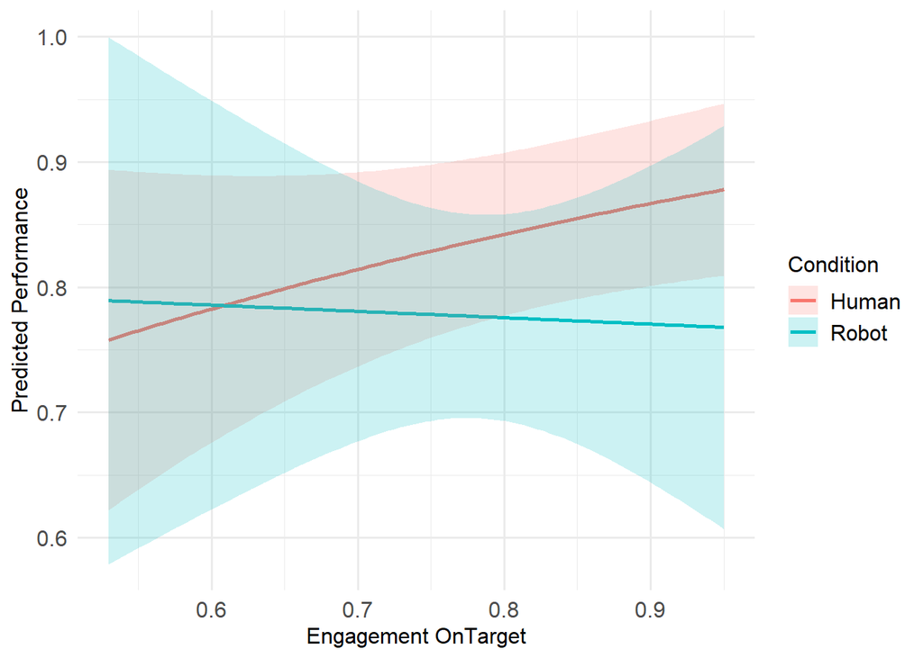

```
##
## ====================
## Predictor: Engagement_OffTarget
## # A tibble: 6 × 6
##   term                                estimate std.error statistic p.value stars
##   <chr>                                  <dbl>     <dbl>     <dbl>   <dbl> <chr>
## 1 (Intercept)                         -1.24e+1    4.34     -2.86   4.19e-3 "**"
## 2 Engagement_OffTarget                -2.43e+0    1.29     -1.88   6.03e-2 "."
## 3 ConditionRobot                      -1.05e+0    0.576    -1.83   6.72e-2 "."
## 4 VBMAPP                               8.99e+0    2.70      3.33   8.62e-4 "***"
## 5 time_c                               1.26e-3    0.0754    0.0167 9.87e-1 ""
## 6 Engagement_OffTarget:ConditionRobot  4.08e+0    3.40      1.20   2.31e-1 ""
```

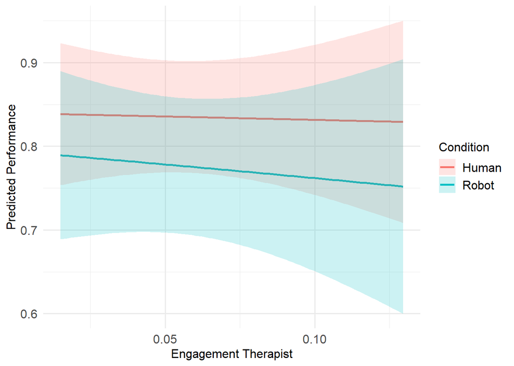

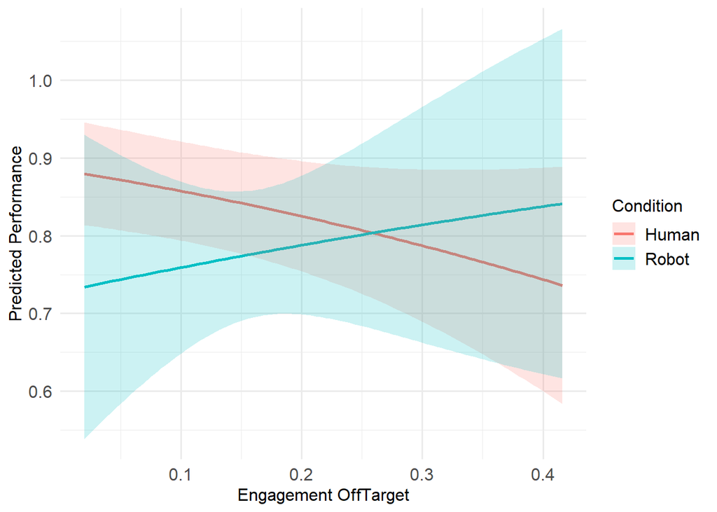

```r
library(glmmTMB)
library(broom.mixed)
library(ggplot2)
library(dplyr)

# Load dataset (adjust path as needed)
df <- read.csv("~/GitHub/Circle-Time-Data-Analyses/CircleTimeData-VBMAPP.csv")

# Ensure output folder exists
if (!dir.exists("figs")) dir.create("figs")

# Convert condition to factor and center time
df$Condition <- factor(df$Condition, levels = c(1, 2), labels = c("Human", "Robot"))
df$time_c <- scale(df$time, center = TRUE, scale = FALSE)

# Response and predictors
response <- "Performance_Positive"
predictors <- c(
  "Affect_Positive", "Affect_Negative",
  "Communication_with_Instructor", "Communication_with_Instructor_Prompted",
  "Communication_with_Therapist", "Communication_with_Indeterminent",
  "Engagement_OnTarget", "Engagement_Therapist", "Engagement_OffTarget"
)

# Significance star function
sig_stars <- function(p) {
  if (is.na(p)) return("")
  if (p < 0.001) return("***")
  else if (p < 0.01) return("**")
  else if (p < 0.05) return("*")
  else if (p < 0.1) return(".")
  else return("")
}

# Beta transform
n <- nrow(df)
df[[response]] <- (df[[response]] * (n - 1) + 0.5) / n

# Loop through predictors
for (pred in predictors) {
  form <- as.formula(paste(response, "~", pred, "* Condition + VBMAPP + time_c + (1 | Subject)"))
  model <- glmmTMB(form, data = df, family = beta_family())
  results <- broom.mixed::tidy(model, effects = "fixed")
  results$stars <- sapply(results$p.value, sig_stars)

  cat("\n====================\n")
  cat("Predictor:", pred, "\n")
  print(results[, c("term", "estimate", "std.error", "statistic", "p.value", "stars")])

  # Prediction data
  new_data <- expand.grid(
    pred_val = seq(min(df[[pred]], na.rm = TRUE), max(df[[pred]], na.rm = TRUE), length.out = 100),
    Condition = factor(c("Human", "Robot"), levels = c("Human", "Robot")),
    VBMAPP = mean(df$VBMAPP, na.rm = TRUE),
    time_c = 0,
    Subject = NA
  )
  colnames(new_data)[1] <- pred

  preds <- predict(model, newdata = new_data, type = "response", se.fit = TRUE)
  new_data$predicted <- preds$fit
  new_data$lower <- preds$fit - 1.96 * preds$se.fit
  new_data$upper <- preds$fit + 1.96 * preds$se.fit

  # Combined plot
  p <- ggplot(new_data, aes_string(x = pred, y = "predicted", color = "Condition", fill = "Condition")) +
    geom_line(size = 1) +
    geom_ribbon(aes(ymin = lower, ymax = upper), alpha = 0.2, color = NA) +
    labs(
      x = gsub("_", " ", pred),
      y = "Predicted Performance"
    ) +
    theme_minimal(base_size = 12) +
    theme(
      plot.title = element_blank(),
      axis.title = element_text(size = 12),
      axis.text = element_text(size = 12),
      legend.title = element_text(size = 12),
      legend.text = element_text(size = 12)
    )

  pdf_file <- paste0("figs/predictor_", pred, "_combined.pdf")
  ggsave(pdf_file, plot = p, width = 6, height = 4)

  print(p)
}
```